# Instrumentation

Marc Nicollerat

# 7 Beschleunigungssensor

- Prinzip
- Aufstellen von Gleichungen
- Dynamisches Verhalten
- Prinzipien der Messung
- Ausführungsvarianten

## 7.1 Prinzip des Beschleunigungssensors

- Mit einer Feder und einem Dämpfer aufgehängte Masse

[figure not shown]

Figure 1: Prinzip des Beschleunigungssensors

Der Sensor misst die Position der Masse in Bezug auf das Fahrgestell ($x-x_m$). Diese Messung kann auf verschiedene Arten erfolgen: Piezo-Sensor, kapazitiver Sensor, induktiver Sensor …

[figure not shown]

Piezo-Resistiver Beschleunigungsmesser

## 7.2 Realisation

Die Komponenten eines Beschleunigungssensors sind

- Eine Masse
- Eine Feder, die ein Teil der Struktur, ein Blatt,… sein kann.
- Ein Dämpfungssystem. Die Dämpfung wird in der Regel durch das Gas verursacht, das die Masse umgibt.
- Eine Messung der Position der Masse. Es gibt verschiedene Möglichkeiten, diese Position zu messen.

## 7.3 Gleichungen für Beschleunigungssensoren

Wenn man das Fahrgestell beschleunigt, übertragen die Feder und der Stoßdämpfer eine Kraft auf die Masse.

Auf der Grundlage von Figure 1 werden die Kräfte wie folgt ausgedrückt:

$$F_{spring} = K_f \cdot (x-x_m), F_{damper}= c \cdot (v-v_m) [N]
\qquad(1)$$

Wenn man Newtons Gesetz über die aufgehängte Masse anwendet, erhält man (unter der Voraussetzung $\Delta x = x-x_m$) :
$$\begin{align}
m \cdot a_m &= F_{spring} + F_{damper} \\
&= K_f \cdot \Delta x + c \cdot \Delta \dot x
\end{align}
\qquad(2)$$

Das Ziel ist es, die Beschleunigung des Fahrgestells zu erhalten, also die Größe $\ddot x$. Ausgehend vom Ausdruck von $\Delta x$ und den ersten und zweiten Ableitungen kann man Equation 2 in dieser Form schreiben ($a_m=\ddot x_m$):

$$\ddot x = \Delta \ddot x + \ddot x_m = \Delta \ddot x + \frac{K_f}{m} \Delta x + \frac{c}{m} \Delta \dot x
\qquad(3)$$

## 7.4 Gleichungen weiter…

$$\Delta \ddot x + 2 \delta_0 \omega_0 \Delta \dot x + \omega_0^2 \Delta x = a
\qquad(4)$$

Wo wir zwei wichtige Parameter der Dynamik definiert haben:

- die **Eigenpulsation**

$$\omega_0=\sqrt{\frac{k_f}{m}}$$

- und **die Abschreibung**
  $$\delta_0 = \frac{1}{2 \omega_0}\frac{c}{m}= \frac{\omega_0 c}{2k_f}$$

Die Eigenpulsation hängt von der Federkraft und der Masse ab. Mit dem Stoßdämpfer kann die Dämpfung kontrolliert werden, um *Schwingungen* zu vermeiden.

## 7.5 Übergangsregime und stationärer Zustand

Wenn eine Beschleunigung auf den Sensor einwirkt, misst er diese Änderung gemäß der dynamischen Gleichung Equation 4. Nach einer gewissen Zeit stellt sich ein stationärer Zustand ein. Dann gilt $\Delta \ddot x=0, \Delta \dot x=0$.

Die Beziehung wird zu :

$$a= \frac{k_f}{m}\Delta x$$

Ein Beispiel für einen Transienten findet sich auf Figure 2.

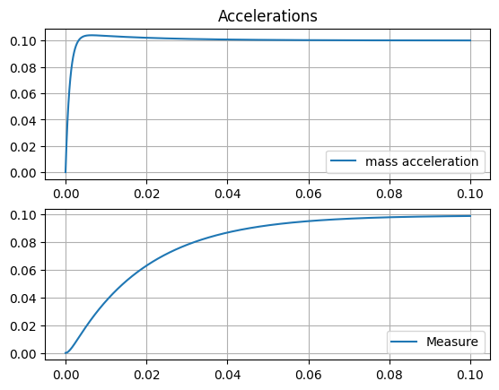

Figure 2: Transitoires observés lors de l’apparition d’une accélération constante de $a=0.1[m/s^2]$

Der Sensor liefert eine repräsentative Messung der Beschleunigung, sofern die Änderungsgeschwindigkeit der Beschleunigung im Vergleich zur Eigenfrequenz der Masse und der Feder gering ist.

## 7.6 Charakteristik des Sensors

Der Beschleunigungssensor wird durch seine *Impulsantwort* oder *Frequenzantwort* charakterisiert. Letztere wird am häufigsten verwendet.

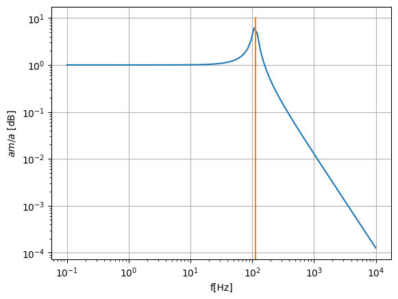

Figure 3: Diagramme de Bode de l’accéléromètre avec une résonance indésirable.

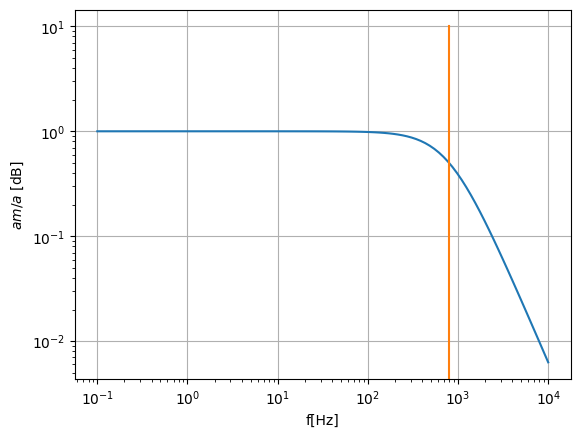

Figure 4: Diagramme de Bode de l’accéléromètre avec un bon amortissement.

**Testen Sie**

Das jupyter notebook ex_captor-acceleration_sol.ipynb enthält eine Simulation des Sensors. Es ist möglich, die Parameter zu ändern, um ihren Einfluss zu beurteilen.

## 7.7 Empfindlichkeit des Sensors

Das Design ist ein Kompromiss zwischen Genauigkeit und Frequenz. Je geringer die Beschleunigung ist, die man messen will, desto größer muss die Masse sein.

[figure not shown]

Beispiel einer Kistler-Spezifikation

**Note**

Um kleine Beschleunigungen zu messen, muss der Sensor eine größere Masse haben, daher sinkt seine Resonanzfrequenz.

## 7.8 Prinzipien der Beschleunigungsmessung

Das Funktionsprinzip ist bei allen Sensoren gleich und basiert auf einer aufgehängten Masse. Es gibt Abweichungen, je nachdem, wie die Bewegung der Masse gemessen wird.

- Piezoelektrische Sensoren

Diese Art von Beschleunigungssensoren besteht aus einer Masse, die von einem piezoelektrischen Element getragen wird. Mithilfe dieses Elements wird die von der Masse ausgeübte Kraft gemessen. Es gibt eine elektrische Ladung ab, die proportional zur Trägheitskraft dieser Masse, also zur Beschleunigung, ist. Das Piezoelement hat eine Eigenelastizität, die bei der Berechnung der *Eigenfrequenz* berücksichtigt werden muss.

[figure not shown]

Figure 5: Prinzip des piezoelektrischen Beschleunigungsmessers

## 7.9 Modell des piezoelektrischen Sensors

Der piezoelektrische Sensor funktioniert nicht statisch, er kann nur Vibrationen messen. Wenn eine Kraft aufgebracht wird, gibt er eine Ladung gemäß der folgenden Gleichung ab:

$$Q=\beta \cdot F \quad [C]
\qquad(5)$$

Mit $Q$ die in *Coulombs* freigesetzte Last, wenn eine Kraft $F$ ausgeübt wird, $\beta$ ist ein Geometriekoeffizient. Ein Strom wird erzeugt, wenn sich die Kraft gemäß der Gleichung Equation 6 ändert.

$$I=\frac{dQ}{dt}=\beta \frac{dF}{dt}
\qquad(6)$$

Wenn F eine *Vibration* der Form $F=\hat F_0 \sin(\omega t)$ ist, gilt also
$$I=\beta \cdot \hat F_0 \cdot \omega \cos(\omega t) = \hat I_0 \cos(\omega t)$$

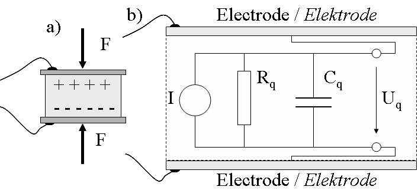

Figure 6: Vorlage

Nach dem Schema auf Figure 6 kann man die Spannung, die entsteht, wenn man eine Kraft anwendet $F$, aus der Beziehung zwischen Spannung und Ladung des Kondensators berechnen:
$$Q = C \cdot U \Rightarrow U=\frac{\beta \cdot F}{C}
\qquad(7)$$

## 7.10 Beispiel für einen Piezo-Beschleunigungssensor

Die Figure 7 zeigt ein Beispiel für einen Beschleunigungsmesser mit piezoelektrischer Messung.

- Beispiel mit Kistler 8205B

[figure not shown]

Figure 7: Auszug aus dem Datasheet

- Die Empfindlichkeit wird in pC/g (Pico-Coulomb pro g) angegeben.
- Der Sensor ist für den Anschluss an einen *Ladungsverstärker* vorgesehen.

## 7.11 Ladungsverstärker

Der Ladungsverstärker ermöglicht es, das Signal in eine gebräuchlichere Form zu bringen:

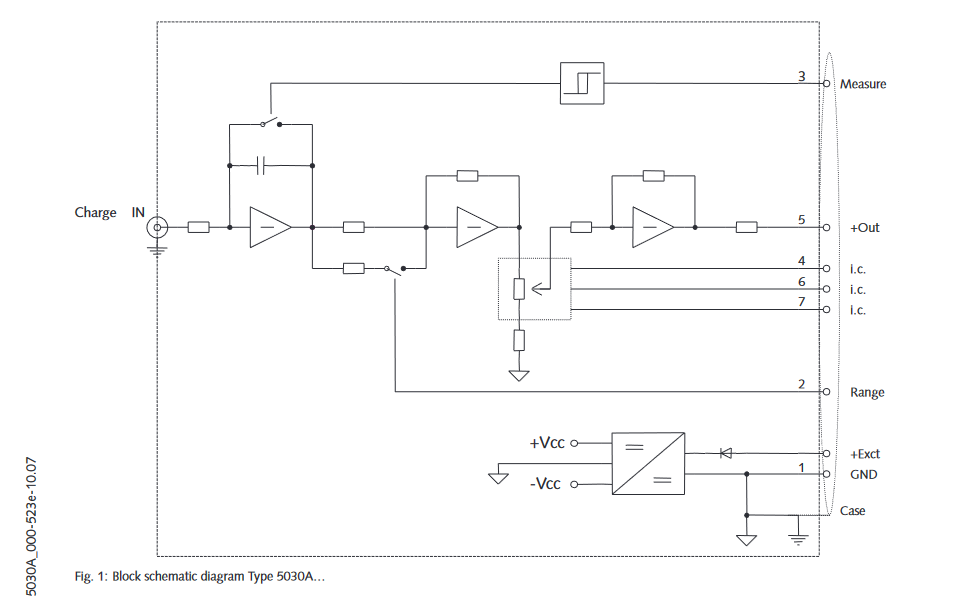

Schema eines Kistler-Ladungsverstärkers. Man findet einen *Integrator*, eine *Reset*-Schaltung und einen Verstärker mit Verstärkungsoptionen.

**Note**

Den Verstärker gibt es in verschiedenen Varianten, mit analogem oder digitalem Ausgang wie IO-link.

## 7.12 Prinzipien der Beschleunigungsmessung, Fortsetzung

- Piezo-resistive Sensoren

Piezoresistive Beschleunigungssensoren bestehen aus einer Masse, die von elastischen Elementen getragen wird. Dieses Blatt ist mit 2 oder 4 piezoresistiven DMS ausgestattet, die als Wheatstone-Brücke montiert sind. Der elektrische Widerstand dieser DMS ändert sich mit der Verformung der Klinge, also mit der Beschleunigung der Masse.

Bei einem Strom $I$, entwickelt sich die Spannung $V_r$ am Sensor gemäß einer Gleichung der Form
$$V_r = R_0 \left[ 1 + \pi_L \sigma_{xx} + \pi_T(\sigma_{yy}+\sigma_{zz})\right] I$$

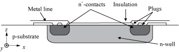

Piezo-Resistiver Sensor

**Info**

Die Piezoresistivität ähnelt dem Dehnungsmessstreifen. Es treten zwei Phänomene auf:

| Die mechanische Längenänderung verursacht eine Änderung der *geometrischen* Festigkeit aufgrund der Längenänderung. | $R=\frac{l+\Delta l}{S}\rho$ |
| --- | --- |
| Die Spannung, die in den Materialien entsteht, bewirkt eine Veränderung der *spezifischen* Festigkeit. | $\rho_\sigma = \frac{\left(\frac{\partial \rho}{\rho} \right)}{\epsilon}$ |

[Details hier](https://en.wikipedia.org/wiki/Piezoresistive_effect#Piezoresistors)

## 7.13 Prinzip der Beschleunigungsmessung, noch

- Kapazitiver Sensor

Die Verschiebung d der seismischen Masse m zwischen den Armaturen (rot und blau) führt zu Kapazitätsänderungen, die eine Funktion der Beschleunigung sind.

[figure not shown]

Modell des kapazitiven Beschleunigungssensors

Die Masse ist durch ein Federsystem aufgehängt. Die Dämpfung kann durch die Luft erzeugt werden, die die aufgehängte Masse umgibt.

## 7.14 Noch mehr Varianten von Beschleunigungssensoren

- Geophon

Dieser Sensor wird zur Erkennung von seismischen Erschütterungen verwendet. Er hat eine sehr geringe Bandbreite. Das Prinzip besteht darin, eine induzierte Spannung an einer Spule zu messen. Der Aufbau ist mit dem eines Lautsprechers vergleichbar.

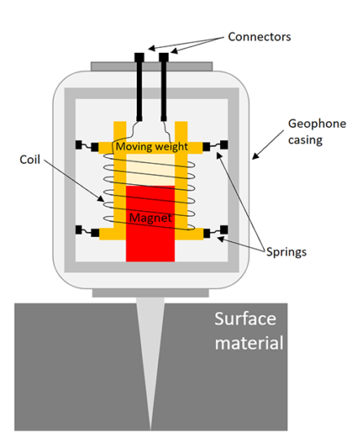

Prinzip des Geophons

## 7.15 Varianten im ganz Kleinen

- Micro Electro Mechanical Systems : **MEMs**

Die Herstellung von mechanischen Komponenten auf Silizium ermöglicht es, Beschleunigungssensoren zu realisieren, die mit ihrer Elektronik integriert sind.

[figure not shown]

Integrierter Beschleunigungssensor

Man kann verschiedene Arten von Sensoren realisieren, wie z. B. die IMUs (Inertial Measurement Units), die man in Smartphones findet.

## 7.16 Beschleunigungssensor mit Servosteuerung

Das Prinzip besteht darin, der Bewegung der Masse durch ein aktives System entgegenzuwirken und die Kraft zu messen, die nötig ist, um die Bewegung zu verhindern. Diese Kraft ist proportional zur Beschleunigung.

Die wesentlichen Merkmale dieser Art von Sensor sind folgende:

- hohe Genauigkeit (Fehler von weniger als 0,1 % des Messbereichs),
- sehr gute Auflösung (10-6 g),
- Messbereich: je nach Modell von ± 1 g bis ± 50 g,
- hohe Kosten.

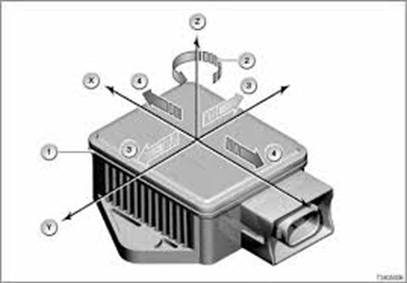

Servobeschleunigungssensor

## 7.17 Übungen

- Ein bisschen Übung: ex_7.2_beschleunigungsmesser_piezo.ipynb
- Übungen Instr_7_übungen
  - Mindestens Übung 7.1